# 0 赛题背景

赛题链接：[“中国软件杯”大学生软件设计大赛——龙源风电赛道](https://aistudio.baidu.com/aistudio/competition/detail/887/0/introduction)

随着清洁能源的快速发展，风力发电已经成为可再生能源的重要组成部分，然而风具有随机性特点，常规天气预报无法准确反映出风电场所在区域的真实风速，从而造成发电功率预测准确率低下，影响电力供需平衡。因此，提高风电功率预测的准确性，为电网调度提供科学支撑，对我国能源产业有十分重要的价值。

此次赛题由百度飞桨和龙源电力设置，数据集由全球最大风电运营企业龙源电力提供，采集自真实风力发电数据，要求选手基于百度飞桨PaddlePaddle设计一个可以通过深度学习技术实现对风力发电进行功率预测及管理的软件系统。

# 1 赛题数据

本赛题数据集由全球最大风电运营企业龙源电力提供，采集自真实风力发电数据。 预选赛训练数据和区域赛训练数据分别为不同10个风电场近一年的运行数据共30万余条，每15分钟采集一次，包括风速、风向、温度、湿度、气压和真实功率等，具体的数据字段中英文对应如下：

- WINDSPEED 预测风速
- WINDDIRECTION 风向
- TEMPERATURE 温度
- HUMIDITY 湿度
- PRESSURE 气压
- PREPOWER 预测功率（系统生成）
- ROUND(A.WS,1) 实际风速
- ROUND(A.POWER,0) 实际功率（计量口径一）
- YD15 实际功率（预测目标，计量口径二）

> 注：预测风速是由权威的气象机构，像是中央气象台、欧洲国家气象中心等发布的商业气象数据源。从时间线来说，实际功率预测需要提前36个小时、72个小时、240的小时等获得数值天气预报，从而进行功率的预测。

考虑到风电场的特殊性，不同风机间的地理位置也是序列预测的一个重要参考价值。但是本次比赛未给出相关信息，因此我们可以考虑用纯时间序列预测生成基线结果。

## 1.1 注意事项

为更加真实地模拟风电企业生产运行的实际情况，在本次比赛中，用于评测的数据集中，除历史数据外，还会提供预测时间段从天气预报中获得的数据字段，包括：

- WINDSPEED 预测风速
- WINDDIRECTION 风向
- TEMPERATURE 温度
- HUMIDITY 湿度
- PRESSURE 气压

**本基线未使用到上述信息，选手们在优化模型时，可以尝试利用好天气预报数据，以取得更好的预测结果。**

# 2 PaddleTS模型库

[PaddleTS](https://paddlets.readthedocs.io/zh_CN/latest/)是一款基于飞桨深度学习框架的开源时序建模算法库，其具备统一的时序数据结构、全面的基础模型功能、丰富的数据处理和分析算子以及领先的深度时序算法，可以帮助开发者实现时序数据处理、分析、建模、预测全流程，在预测性维护、智慧能耗分析、价格销量预估等场景中有重要应用价值。

本文就以[PaddleTS](https://paddlets.readthedocs.io/zh_CN/latest/source/modules/models/overview.html)模型库的实现风机功率预测基线开发为例，介绍如何使用模型库快速、批量生成多路时间序列的预测结果。

```python
# 安装模型库
!pip install paddlets
!pip install ray
!pip install optuna
```

```python
#导入需要的包
%matplotlib inline
import os
import pandas as pd
import numpy as np
import matplotlib.pyplot as plt
from sklearn.preprocessing import StandardScaler, MinMaxScaler
import datetime
import paddlets
from paddlets import TSDataset
from paddlets import TimeSeries
from paddlets.models.forecasting import MLPRegressor, LSTNetRegressor
from paddlets.transform import Fill, StandardScaler
from paddlets.metrics import MSE, MAE
from paddlets.analysis import AnalysisReport, Summary
from paddlets.datasets.repository import get_dataset
import warnings
warnings.filterwarnings('ignore')
```

# 3 数据集分析

## 3.1 数据预处理

```python
# 解压缩数据集
!unzip -O GBK 功率预测竞赛赛题与数据集.zip
```

本次比赛重点侧重于模型算法的落地应用，因此，数据集高度贴近风电企业实际情况，选手开发数据集处理方法，需要同时适配不同格式的风机数据。预选赛提供10个风场的数据，区域赛会提供新的10个风场数据用于新的训练和预测，数据格式的情况可能会更为复杂，本文总结了风场数据可能存在的各种情况：

[figure not shown]

针对以上问题，可以确定如下的数据集处理思路：

1. 将风机数据统一为csv格式
2. 将同一个风机的多条数据进行拼接，按时间戳进行排序，合成一个文件

```python
def data_preprocess(data_dir):
    files = os.listdir(data_dir)
    # 第一步，完成数据格式统一
    for f in files:
        # 获取文件路径
        data_file = os.path.join(data_dir, f)
        # 获取文件名后缀
        data_type = os.path.splitext(data_file)[-1]
        # 获取文件名前缀
        data_name = os.path.splitext(data_file)[0]
        # 如果是excel文件，进行转换
        if data_type == '.xlsx':
            # 需要特别注意的是，在读取excel文件时要指定空值的显示方式，否则会在保存时以字符“.”代替，影响后续的数据分析
            data_xls = pd.read_excel(data_file, index_col=0, na_values='')
            data_xls.to_csv(data_name + '.csv', encoding='utf-8')
            # 顺便删除原文件
            os.remove(data_file)
    # 第二步，完成多文件的合并，文件目录要重新更新一次
    files = os.listdir(data_dir)
    for f in files:
        # 获取文件路径
        data_file = os.path.join(data_dir, f)
        # 获取文件名前缀
        data_basename = os.path.basename(data_file)
        # 检查风机数据是否有多个数据文件
        if len(data_basename.split('-')) > 1:
            merge_list = []
            # 找出该风机的所有数据文件
            matches = [ f for f in files if (f.find(data_basename.split('-')[0] + '-') > -1)]
            for i in matches:
                # 读取风机这部分数据
                data_df = pd.read_csv(os.path.join(data_dir, i), index_col=False, keep_default_na=False)
                merge_list.append(data_df)
            if len(merge_list) > 0:
                all_data = pd.concat(merge_list,axis=0,ignore_index=True).fillna(".")
                all_data.to_csv(os.path.join(data_dir, data_basename.split('-')[0]+ '.csv'),index=False)
            for i in matches:
                # 删除这部分数据文件
                os.remove(os.path.join(data_dir, i))
            # 更新文件目录
            files = os.listdir(data_dir)
```

```python
data_preprocess('功率预测竞赛赛题与数据集')
```

至此，我们完成了数据集的批量预处理，将各种风机不同格式、不同数量文件的数据集进行了统一。这样，在后续的时序数据预测中，我们只需要对csv格式的时序数据进行处理即可。

```python
os.listdir('功率预测竞赛赛题与数据集')
```

在这里，我们也需要准备一个存放预测结果的文件目录。

```python
!mkdir submit
```

## 3.2 风机数据EDA

由于赛题给出的不同风机采集数据字段都是一致的，仅仅是文件格式和数量不同。因此，在我们统一风机数据文件格式后，只需要抽出其中一两个风机的数据进行探索性数据分析即可——其它风机的情况是大体相同的。

在这里，我们取刚才转换格式并合并文件的一个风机数据进行分析，比如04号风机（如果前面的数据处理有错误，在这里就能发现）。

```python
# 读取一份数据文件，这里需要特别注意时间戳字段的格式指定
df = pd.read_csv('功率预测竞赛赛题与数据集/04.csv',parse_dates=['DATATIME'],infer_datetime_format=True,dayfirst=True)
```

```python
# 查看04号风机的运行工况数据
df.head()
```

|  | DATATIME | WINDSPEED | PREPOWER | WINDDIRECTION | TEMPERATURE | HUMIDITY | PRESSURE | ROUND(A.WS,1) | ROUND(A.POWER,0) | YD15 |
| --- | --- | --- | --- | --- | --- | --- | --- | --- | --- | --- |
| 0 | 2021-10-02 00:00:00 | 4.1 | 6744.4 | 39 | 24.6 | 94 | 1008 | 4.0 | 7078.0 | 5906.0 |
| 1 | 2021-10-02 00:00:00 | 4.1 | 7949.5 | 39 | 24.6 | 94 | 1008 | 4.0 | 7078.0 | 5906.0 |
| 2 | 2021-10-02 00:15:00 | 4.1 | 6622.2 | 38 | 24.6 | 94 | 1008 | 4.5 | 11209.0 | 8721.0 |
| 3 | 2021-10-02 00:15:00 | 4.1 | 7926.1 | 38 | 24.6 | 94 | 1008 | 4.5 | 11209.0 | 8721.0 |
| 4 | 2021-10-02 00:30:00 | 4.0 | 6522.1 | 35 | 24.5 | 94 | 1008 | 4.6 | 11467.0 | 11973.0 |

```python
df.columns
```

```
Index(['DATATIME', 'WINDSPEED', 'PREPOWER', 'WINDDIRECTION', 'TEMPERATURE',
       'HUMIDITY', 'PRESSURE', 'ROUND(A.WS,1)', 'ROUND(A.POWER,0)', 'YD15'],
      dtype='object')
```

```python
df.info()
```

```
<class 'pandas.core.frame.DataFrame'>
RangeIndex: 89868 entries, 0 to 89867
Data columns (total 10 columns):
 #   Column            Non-Null Count  Dtype
---  ------            --------------  -----
 0   DATATIME          89868 non-null  datetime64[ns]
 1   WINDSPEED         89868 non-null  float64
 2   PREPOWER          89868 non-null  float64
 3   WINDDIRECTION     89868 non-null  int64
 4   TEMPERATURE       89868 non-null  float64
 5   HUMIDITY          89868 non-null  int64
 6   PRESSURE          89868 non-null  int64
 7   ROUND(A.WS,1)     89349 non-null  float64
 8   ROUND(A.POWER,0)  89349 non-null  float64
 9   YD15              89552 non-null  float64
dtypes: datetime64[ns](1), float64(6), int64(3)
memory usage: 6.9 MB
```

由于风机工况数据文件并不大，读者也可以直接打开文件查看。这时会发现最后一天的`ROUND(A.POWER,0)`,`YD15`两个字段数据基本为空，这就是出题方希望我们预测填空的数据。

不过，这里需要我们注意的是，`csv`文件里的时间戳未必是顺序排列的，最后一天的时间戳未必在文件末段，由于PaddleTS会自动对时间排序，我们在下面数据分析的时候也能发现这个问题。

```python
df.tail()
```

接下来，我们使用PaddleTS快速完成数据集的初步分析。 PaddleTS的Analsis模块能够帮助我们更简便地理解数据，同时，它还提供了多种多样的Anayzer帮助用户洞察数据，也提供了Report API给用户展示多种Analyzer组合分析的数据。

```python
# 因为数据批次不同，数据集中有一些时间戳重复的脏数据，送入paddlets前要进行处理，本赛题要求保留第一个数据
df.drop_duplicates(subset = ['DATATIME'],keep='first',inplace=True)
```

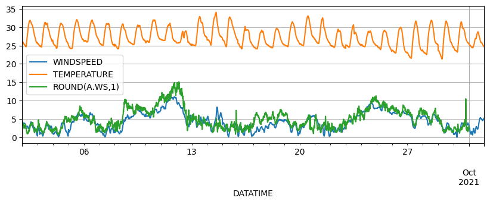

```python
# 我们选取最后30天的风机工况数据进行可视化
target_cov_dataset = TSDataset.load_from_dataframe(
    df[-4*24*30:],
    time_col='DATATIME',
    target_cols='YD15',
    observed_cov_cols=['WINDSPEED', 'PREPOWER', 'WINDDIRECTION', 'TEMPERATURE',
       'HUMIDITY', 'PRESSURE', 'ROUND(A.WS,1)', 'ROUND(A.POWER,0)'],
    freq='15min',
    fill_missing_dates=False
)
# 由于不同指标的数值差异较大，在绘图时选取数值范围相近的组合分开绘制可视化图表
target_cov_dataset.plot(['WINDSPEED', 'TEMPERATURE', 'ROUND(A.WS,1)'])
```

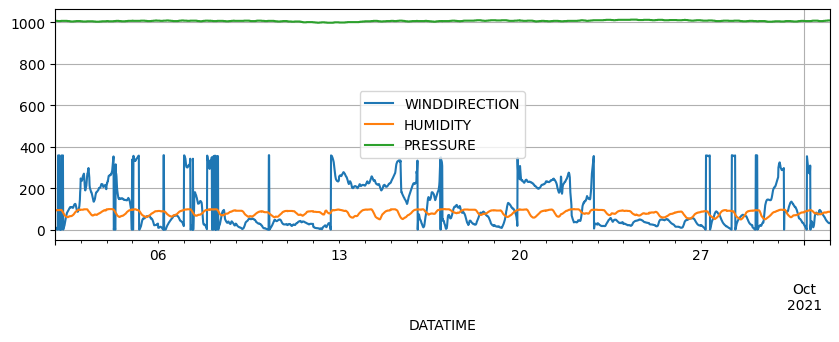

```python
target_cov_dataset.plot(['WINDDIRECTION', 'HUMIDITY', 'PRESSURE'])
```

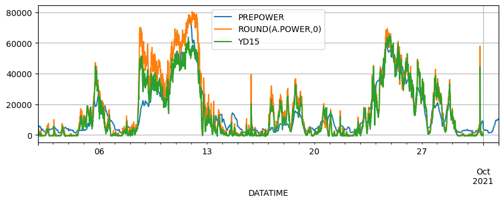

```python
target_cov_dataset.plot(['PREPOWER', 'ROUND(A.POWER,0)','YD15'])
```

```python
target_cov_dataset.summary()
```

|  | YD15 | WINDSPEED | PREPOWER | WINDDIRECTION | TEMPERATURE | HUMIDITY | PRESSURE | ROUND(A.WS,1) | ROUND(A.POWER,0) |
| --- | --- | --- | --- | --- | --- | --- | --- | --- | --- |
| missing | 0.032986 | 0.000000 | 0.000000 | 0.000000 | 0.000000 | 0.000000 | 0.000000 | 0.034028 | 0.034028 |
| count | 2785.000000 | 2880.000000 | 2880.000000 | 2880.000000 | 2880.000000 | 2880.000000 | 2880.000000 | 2782.000000 | 2782.000000 |
| mean | 14332.472531 | 4.243854 | 14898.320499 | 110.196875 | 27.239931 | 81.825694 | 1006.615972 | 5.030410 | 17404.443925 |
| std | 17475.732789 | 2.368603 | 16348.756167 | 101.818709 | 2.493907 | 12.432304 | 2.870195 | 2.798523 | 20852.864000 |
| min | -841.000000 | 0.000000 | 1194.570760 | 0.000000 | 21.300000 | 49.000000 | 998.000000 | 0.700000 | -355.000000 |
| 25% | 247.000000 | 2.400000 | 3507.291667 | 28.000000 | 25.300000 | 72.000000 | 1005.000000 | 2.800000 | 902.500000 |
| 50% | 5775.000000 | 3.900000 | 7376.846199 | 62.000000 | 26.700000 | 84.000000 | 1007.000000 | 4.400000 | 7770.000000 |
| 75% | 25184.000000 | 5.900000 | 20275.775000 | 202.000000 | 29.200000 | 92.000000 | 1008.000000 | 6.800000 | 28848.500000 |
| max | 64725.000000 | 11.000000 | 75210.200000 | 359.000000 | 34.100000 | 99.000000 | 1013.000000 | 15.100000 | 80409.000000 |

```python
target_cov_dataset.max()
```

```
YD15                64725.0
WINDSPEED              11.0
PREPOWER            75210.2
WINDDIRECTION         359.0
TEMPERATURE            34.1
HUMIDITY               99.0
PRESSURE             1013.0
ROUND(A.WS,1)          15.1
ROUND(A.POWER,0)    80409.0
dtype: float64
```

Analsis模块目前支持的分析器有:

- [Summary](https://paddlets.readthedocs.io/zh_CN/latest/source/api/paddlets.analysis.base_analyzers.html) : 总结指标，目前支持均值、方差、最小值、25%中位数、50%中位数、75%中位数、最大值、缺失百分比、平稳性p值。
- [Max](https://paddlets.readthedocs.io/zh_CN/latest/source/api/paddlets.analysis.base_analyzers.html) : 计算给定列的最大值。
- [FFT](https://paddlets.readthedocs.io/zh_CN/latest/source/api/paddlets.analysis.frequency_domain.html) : 基于快速傅里叶变换的信号频域分析。
- [STFT](https://paddlets.readthedocs.io/zh_CN/latest/source/api/paddlets.analysis.frequency_domain.html) : 基于短时傅里叶变换的信号时频分析。
- [CWT](https://paddlets.readthedocs.io/zh_CN/latest/source/api/paddlets.analysis.frequency_domain.html) : 基于连续小波变换的信号时频分析。

我们也可以根据实际需求让它生成对应的时序数据分析报告。

```python
report = AnalysisReport(target_cov_dataset, ["summary"])
# 加入时频分析后，需要较长的计算时间
# report = AnalysisReport(target_cov_dataset, ["summary","fft","stft","cwt"])
```

```
[2023-04-03 10:57:44,069] [paddlets.analysis.analysis_report] [INFO] save report succcess, save at ./analysis_report.docx
```

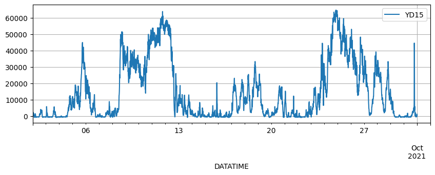

```python
report.export_docx_report()
```

# 4 模型应用

## 4.1 数据集准备

在数据集分析时，我们可以不对数据缺失值进行处理以保持数据原貌。但是在模型训练时，则必须指定缺失值的处理方式，否则训练会报错。同时，PaddleTS要求输入的协变量为float格式，对于个别字段，需要进行指定。

```python
df = pd.read_csv('功率预测竞赛赛题与数据集/01.csv',parse_dates=['DATATIME'],infer_datetime_format=True,dayfirst=True,dtype={'WINDDIRECTION':np.float64, 'HUMIDITY':np.float64, 'PRESSURE':np.float64})
```

```python
# 因为数据批次不同，数据集中有一些时间戳重复的脏数据，送入paddlets前要进行处理，本赛题要求保留第一个数据
df.drop_duplicates(subset = ['DATATIME'],keep='first',inplace=True)
```

```python
df.info()
```

```
<class 'pandas.core.frame.DataFrame'>
Int64Index: 26208 entries, 0 to 34586
Data columns (total 10 columns):
 #   Column            Non-Null Count  Dtype
---  ------            --------------  -----
 0   DATATIME          26208 non-null  datetime64[ns]
 1   WINDSPEED         26208 non-null  float64
 2   PREPOWER          26208 non-null  float64
 3   WINDDIRECTION     26208 non-null  float64
 4   TEMPERATURE       26208 non-null  float64
 5   HUMIDITY          26208 non-null  float64
 6   PRESSURE          26208 non-null  float64
 7   ROUND(A.WS,1)     25943 non-null  float64
 8   ROUND(A.POWER,0)  25943 non-null  float64
 9   YD15              26113 non-null  float64
dtypes: datetime64[ns](1), float64(9)
memory usage: 2.2 MB
```

```python
target_cov_dataset = TSDataset.load_from_dataframe(
    df,
    time_col='DATATIME',
    target_cols=['ROUND(A.POWER,0)', 'YD15'],
    observed_cov_cols=['WINDSPEED', 'PREPOWER', 'WINDDIRECTION', 'TEMPERATURE',
       'HUMIDITY', 'PRESSURE', 'ROUND(A.WS,1)'],
    freq='15min',
    fill_missing_dates=True,
    fillna_method = 'pre'
)
```

关于数据集的切分，有两种方式。一是直接指定数据集切分比例；二是根据时序数据的特点，PaddleTS也支持通过时间戳的节点进行划分。

[figure not shown]

```python
# train_dataset, val_test_dataset = target_cov_dataset.split(0.7)
# val_dataset, test_dataset = val_test_dataset.split(0.3)
# train_dataset.plot(add_data=[val_dataset,test_dataset], labels=['Val', 'Test'])
```

由于本项目是一个面向落地应用的场景，选手在设计数据集划分方式时，可以优先考虑通过时间戳划分数据集。

需要注意的是，赛题是这么要求的：

> 算法部分：要求选手基于PaddlePaddle根据官方提供的数据集，设计一种利用当日05:00之前的数据，预测次日00:00至23:45实际功率的方法。准确率按日统计，根据10个风电场平均准确率进行排名；准确率相同的情形下，根据每日单点的平均最大偏差绝对值排名。

所以我们在进行切分时，建议优先按照05:00这个时间点进行划分。

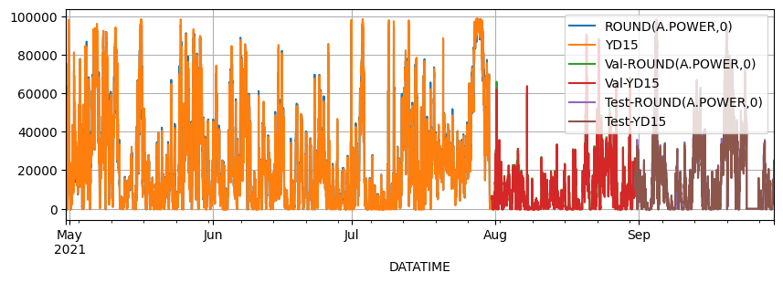

```python
_ , train_dataset = target_cov_dataset.split('2021-04-30 04:45:00')
train_dataset, val_test_dataset = train_dataset.split('2021-07-31 04:45:00')
val_dataset, test_dataset = val_test_dataset.split('2021-08-31 04:45:00')
# 最后一天的工况数据需要预测ROUND(A.POWER,0)和YD15两个字段，而且输入数据只到前一天的早上5点
test_dataset, pred_dataset = test_dataset.split('2021-09-30 04:45:00')
train_dataset.plot(add_data=[val_dataset,test_dataset], labels=['Val', 'Test'])
```

数据处理时，可以将指定列的值缩放为零均值和单位方差来实现归一化转换。

```python
scaler = StandardScaler()
scaler.fit(train_dataset)
train_dataset_scaled = scaler.transform(train_dataset)
val_test_dataset_scaled = scaler.transform(val_test_dataset)
val_dataset_scaled = scaler.transform(val_dataset)
test_dataset_scaled = scaler.transform(test_dataset)
# 如果使用了归一化，在后续模型预测时要进行数据集逆转换
# test_dataset = scaler.inverse_transform(ts_test_scaled)
```

## 4.2 方案一：单模型预测

### 4.2.1 单模型训练

我们先引入LSTM模型，做单模型的单时间序列预测任务示例。

注意到我们需要用前一日05:00之前的风机数据，预测次日00:00至23:45的实际功率——从数据输入，到数据输出，不是连续的。

这与一般时序模型处理的数据情况存在不同，因此我们要进行一些处理，即：

- 用前一日05:00之前的风机数据，预测05:00之后到次日23:45的实际功率
- 对于输出，裁剪掉05:00之后次日00:00之间的预测结果

```python
lstm = LSTNetRegressor(
    in_chunk_len = (24 + 19) * 7 * 4,
    out_chunk_len = (24 + 19) * 4,
    max_epochs=10,
    optimizer_params= dict(learning_rate=5e-3),
)
```

```python
lstm.fit(train_dataset, val_dataset)
```

```
[2023-04-13 23:38:57,682] [paddlets.models.common.callbacks.callbacks] [INFO] epoch 000| loss: 861660534.464798| val_0_mae: 15910.196289| 0:00:17s
[2023-04-13 23:39:14,833] [paddlets.models.common.callbacks.callbacks] [INFO] epoch 001| loss: 702688372.799785| val_0_mae: 13043.845703| 0:00:34s
[2023-04-13 23:39:31,568] [paddlets.models.common.callbacks.callbacks] [INFO] epoch 002| loss: 629983447.554781| val_0_mae: 12294.802734| 0:00:51s
[2023-04-13 23:39:48,294] [paddlets.models.common.callbacks.callbacks] [INFO] epoch 003| loss: 605644464.240311| val_0_mae: 12514.247070| 0:01:07s
[2023-04-13 23:40:05,296] [paddlets.models.common.callbacks.callbacks] [INFO] epoch 004| loss: 653346019.209870| val_0_mae: 12663.069336| 0:01:24s
[2023-04-13 23:40:22,370] [paddlets.models.common.callbacks.callbacks] [INFO] epoch 005| loss: 636977429.988467| val_0_mae: 12120.254883| 0:01:41s
[2023-04-13 23:40:39,917] [paddlets.models.common.callbacks.callbacks] [INFO] epoch 006| loss: 627197534.103258| val_0_mae: 12355.960938| 0:01:59s
[2023-04-13 23:40:56,507] [paddlets.models.common.callbacks.callbacks] [INFO] epoch 007| loss: 649966813.987394| val_0_mae: 15012.541992| 0:02:15s
[2023-04-13 23:41:13,214] [paddlets.models.common.callbacks.callbacks] [INFO] epoch 008| loss: 677125166.586027| val_0_mae: 14301.767578| 0:02:32s
[2023-04-13 23:41:29,917] [paddlets.models.common.callbacks.callbacks] [INFO] epoch 009| loss: 641291815.119218| val_0_mae: 11663.125977| 0:02:49s
[2023-04-13 23:41:29,922] [paddlets.models.common.callbacks.callbacks] [INFO] Stop training because you reached max_epochs = 10 with best_epoch = 9 and best_val_0_mae = 11663.125977
[2023-04-13 23:41:29,923] [paddlets.models.common.callbacks.callbacks] [INFO] Best weights from best epoch are automatically used!
```

```python
subset_test_pred_dataset = lstm.predict(val_dataset)
subset_test_dataset, _ = test_dataset.split(len(subset_test_pred_dataset.target))
```

```python
# 模型评估
mae = MAE()
mae(subset_test_dataset, subset_test_pred_dataset)
```

```
{'ROUND(A.POWER,0)': 16030.454186816549, 'YD15': 15601.535719760628}
```

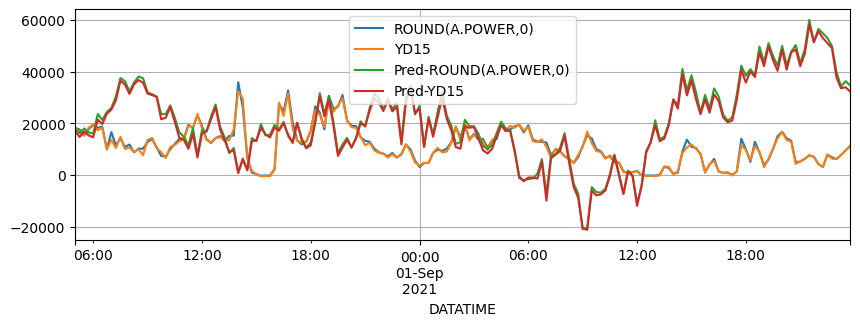

```python
# 预测结果可视化
subset_test_dataset, _ = test_dataset.split(len(subset_test_pred_dataset.target))
subset_test_dataset.plot(add_data=subset_test_pred_dataset, labels=['Pred'])
```

上图显示的是训练模型对1号风机未来（19+24）小时预测结果与测试集实际趋势的对比。

### 4.2.2 单模型保存和加载

```python
# 模型保存
lstm.save("lstm")
```

```python
# 也可以动转静保存
lstm.save("./model", network_model=True, dygraph_to_static=True)
```

```python
# 模型加载
from paddlets.models.model_loader import load
loaded_lstm = load("lstm")
```

### 4.2.3 生成预测结果

```python
# 模型预测
result = loaded_lstm.predict(test_dataset)
result.to_dataframe()[19*4:]
```

|  | ROUND(A.POWER,0) | YD15 |
| --- | --- | --- |
| 2021-10-01 00:00:00 | 29912.177734 | 29194.886719 |
| 2021-10-01 00:15:00 | 20358.554688 | 21656.388672 |
| 2021-10-01 00:30:00 | 29699.613281 | 29963.566406 |
| 2021-10-01 00:45:00 | 27510.537109 | 26607.953125 |
| 2021-10-01 01:00:00 | 16971.984375 | 16437.027344 |
| ... | ... | ... |
| 2021-10-01 22:45:00 | -7202.264648 | -7223.247070 |
| 2021-10-01 23:00:00 | -7145.840332 | -6936.324219 |
| 2021-10-01 23:15:00 | -3206.446045 | -3385.208252 |
| 2021-10-01 23:30:00 | 2323.184082 | 2423.130371 |
| 2021-10-01 23:45:00 | 87.688187 | 660.455383 |

96 rows × 2 columns

```python
# 截取次日预测数据
result = result.to_dataframe()[19*4:]
result = result.reset_index()
# 传入风场风机ID
result['TurbID'] = 1
# 重新调整字段名称和顺序
result.rename(columns={"index": "Datetime"}, inplace=True)
result = result[['TurbID', 'Datetime', 'ROUND(A.POWER,0)', 'YD15']]
```

```python
result.to_csv('submit/01.csv',index=False)
```

## 4.3 方案二：集成模型预测

集成模型是用集成学习的思想去把多个PaddleTS的预测器集合成一个预测器。目前PaddleTS支持两种集成预测器StackingEnsembleForecaster 和 WeightingEnsembleForecaster

步骤包括：

1.准备数据

2.准备模型

3.组装和拟合模型

4.进行回测

5.模型保存与加载

接下来，我们用集成模型来预测1号风机的输出功率变化。首先是准备集成预测器需要的底层模型，这里我们选择RNN，LSTM和MLP。

### 4.3.1 集成模型训练

```python
from paddlets.models.forecasting import MLPRegressor
from paddlets.models.forecasting import LSTNetRegressor
from paddlets.models.forecasting import RNNBlockRegressor

lstm_params = {
    'sampling_stride': (24 + 19) * 4,
    'eval_metrics':["mse", "mae"],
    'batch_size': 8,
    'max_epochs': 20,
    'patience': 10
}
rnn_params = {
    'sampling_stride': (24 + 19) * 4,
    'eval_metrics': ["mse", "mae"],
    'batch_size': 8,
    'max_epochs': 20,
    'patience': 10
}
mlp_params = {
    'sampling_stride': (24 + 19) * 4,
    'eval_metrics': ["mse", "mae"],
    'batch_size': 8,
    'max_epochs': 20,
    'patience': 10,
    'use_bn': True,
}
```

为了保持模型预测的一致性， `in_chunk_len`, `out_chunk_len`, `skip_chunk_len`, 这三个参数已经被提取到集成模型中，在组装模型时统一设定。

```python
from paddlets.ensemble import StackingEnsembleForecaster

reg = StackingEnsembleForecaster(
in_chunk_len= (24 + 19) * 7 * 4,
out_chunk_len= (24 + 19) * 4,
skip_chunk_len=0,
estimators=[(LSTNetRegressor, lstm_params),(RNNBlockRegressor, rnn_params), (MLPRegressor, mlp_params)])
```

```python
# 模型拟合
reg.fit(train_dataset, val_dataset)
```

```
[2023-04-13 23:45:41,784] [paddlets.models.common.callbacks.callbacks] [INFO] epoch 000| loss: 2157854766.545455| val_0_mse: 434634944.000000| val_0_mae: 15134.261719| 0:00:00s
[2023-04-13 23:45:42,201] [paddlets.models.common.callbacks.callbacks] [INFO] epoch 001| loss: 1274874944.000000| val_0_mse: 404811008.000000| val_0_mae: 14455.226562| 0:00:00s
[2023-04-13 23:45:42,616] [paddlets.models.common.callbacks.callbacks] [INFO] epoch 002| loss: 864954938.181818| val_0_mse: 383082656.000000| val_0_mae: 13955.348633| 0:00:01s
[2023-04-13 23:45:43,028] [paddlets.models.common.callbacks.callbacks] [INFO] epoch 003| loss: 654667089.454545| val_0_mse: 364152256.000000| val_0_mae: 13681.997070| 0:00:01s
[2023-04-13 23:45:43,452] [paddlets.models.common.callbacks.callbacks] [INFO] epoch 004| loss: 520725451.636364| val_0_mse: 367876256.000000| val_0_mae: 13655.694336| 0:00:02s
[2023-04-13 23:45:43,903] [paddlets.models.common.callbacks.callbacks] [INFO] epoch 005| loss: 426495889.454545| val_0_mse: 358582400.000000| val_0_mae: 13374.958984| 0:00:02s
[2023-04-13 23:45:44,328] [paddlets.models.common.callbacks.callbacks] [INFO] epoch 006| loss: 366549453.090909| val_0_mse: 364607712.000000| val_0_mae: 13544.072266| 0:00:02s
[2023-04-13 23:45:44,741] [paddlets.models.common.callbacks.callbacks] [INFO] epoch 007| loss: 314228002.909091| val_0_mse: 362071616.000000| val_0_mae: 13440.303711| 0:00:03s
[2023-04-13 23:45:45,167] [paddlets.models.common.callbacks.callbacks] [INFO] epoch 008| loss: 262892445.090909| val_0_mse: 360921376.000000| val_0_mae: 13412.265625| 0:00:03s
[2023-04-13 23:45:45,584] [paddlets.models.common.callbacks.callbacks] [INFO] epoch 009| loss: 221938609.454545| val_0_mse: 358694112.000000| val_0_mae: 13378.511719| 0:00:04s
[2023-04-13 23:45:45,999] [paddlets.models.common.callbacks.callbacks] [INFO] epoch 010| loss: 190502526.545455| val_0_mse: 360426240.000000| val_0_mae: 13350.240234| 0:00:04s
[2023-04-13 23:45:46,464] [paddlets.models.common.callbacks.callbacks] [INFO] epoch 011| loss: 170810132.363636| val_0_mse: 356882144.000000| val_0_mae: 13284.953125| 0:00:05s
[2023-04-13 23:45:46,906] [paddlets.models.common.callbacks.callbacks] [INFO] epoch 012| loss: 148189114.909091| val_0_mse: 360419648.000000| val_0_mae: 13336.097656| 0:00:05s
[2023-04-13 23:45:47,352] [paddlets.models.common.callbacks.callbacks] [INFO] epoch 013| loss: 132365503.272727| val_0_mse: 358436960.000000| val_0_mae: 13260.419922| 0:00:05s
[2023-04-13 23:45:47,787] [paddlets.models.common.callbacks.callbacks] [INFO] epoch 014| loss: 118677271.272727| val_0_mse: 359307424.000000| val_0_mae: 13311.393555| 0:00:06s
[2023-04-13 23:45:48,202] [paddlets.models.common.callbacks.callbacks] [INFO] epoch 015| loss: 105317205.454545| val_0_mse: 363960896.000000| val_0_mae: 13361.411133| 0:00:06s
[2023-04-13 23:45:48,613] [paddlets.models.common.callbacks.callbacks] [INFO] epoch 016| loss: 90016433.454545| val_0_mse: 363362176.000000| val_0_mae: 13335.208984| 0:00:07s
[2023-04-13 23:45:49,026] [paddlets.models.common.callbacks.callbacks] [INFO] epoch 017| loss: 80012225.090909| val_0_mse: 366721696.000000| val_0_mae: 13422.874023| 0:00:07s
[2023-04-13 23:45:49,438] [paddlets.models.common.callbacks.callbacks] [INFO] epoch 018| loss: 73471033.454545| val_0_mse: 367162976.000000| val_0_mae: 13388.984375| 0:00:08s
[2023-04-13 23:45:49,861] [paddlets.models.common.callbacks.callbacks] [INFO] epoch 019| loss: 65201690.909091| val_0_mse: 373351680.000000| val_0_mae: 13544.246094| 0:00:08s
[2023-04-13 23:45:49,865] [paddlets.models.common.callbacks.callbacks] [INFO] Stop training because you reached max_epochs = 20 with best_epoch = 13 and best_val_0_mae = 13260.419922
[2023-04-13 23:45:49,866] [paddlets.models.common.callbacks.callbacks] [INFO] Best weights from best epoch are automatically used!
[2023-04-13 23:45:52,255] [paddlets.models.common.callbacks.callbacks] [INFO] epoch 000| loss: 1096603042.909091| val_0_mse: 332518752.000000| val_0_mae: 11341.488281| 0:00:00s
[2023-04-13 23:45:52,481] [paddlets.models.common.callbacks.callbacks] [INFO] epoch 001| loss: 1096600740.363636| val_0_mse: 332517600.000000| val_0_mae: 11341.460938| 0:00:00s
[2023-04-13 23:45:52,691] [paddlets.models.common.callbacks.callbacks] [INFO] epoch 002| loss: 1096598539.636364| val_0_mse: 332516480.000000| val_0_mae: 11341.433594| 0:00:00s
[2023-04-13 23:45:52,899] [paddlets.models.common.callbacks.callbacks] [INFO] epoch 003| loss: 1096596171.636364| val_0_mse: 332515360.000000| val_0_mae: 11341.407227| 0:00:00s
```

[output cut: 40 more lines]

```python
subset_test_pred_dataset = reg.predict(val_dataset)
subset_test_dataset, _ = test_dataset.split(len(subset_test_pred_dataset.target))
```

```python
# 模型评估
mae = MAE()
mae(subset_test_dataset, subset_test_pred_dataset)
```

```
{'ROUND(A.POWER,0)': 6370.233882897048, 'YD15': 6344.061808114118}
```

从评估指标的表现看，集成模型的表现进步较大。当然，它牺牲了一些训练时间，实际开发时，选手需要综合用户体验和预测效果，进行适当取舍。

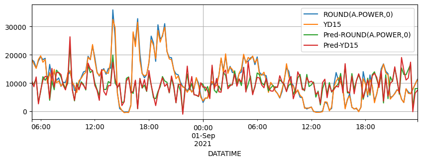

```python
subset_test_dataset, _ = test_dataset.split(len(subset_test_pred_dataset.target))
subset_test_dataset.plot(add_data=subset_test_pred_dataset, labels=['Pred'])
```

### 4.3.2 集成模型保存和加载

顾名思义，集成模型保存的时候是分了多个模型，因此，加载的时候是分别加载的。

```python
reg.save("reg")
```

```python
# 集成模型加载
loaded_model0 = load("./reg/paddlets-ensemble-model0")
loaded_model1 = load("./reg/paddlets-ensemble-model1")
loaded_model2 = load("./reg/paddlets-ensemble-model2")
```

### 4.3.3 生成预测结果

尽管分开加载集成模型显得有些麻烦，但是，我们此时还可以设置不同集成模型的权重，比如：让表现更好的模型权重更大。这样，或许可以进一步提升预测效果。

```python
# 输出集成模型预测结果
loaded_model0.predict(test_dataset).to_dataframe()[19*4:]*0.2 + loaded_model1.predict(test_dataset).to_dataframe()[19*4:]*0.4 + loaded_model2.predict(test_dataset).to_dataframe()[19*4:]*0.4
```

|  | ROUND(A.POWER,0) | YD15 |
| --- | --- | --- |
| 2021-10-01 00:00:00 | 11058.841797 | 11355.408203 |
| 2021-10-01 00:15:00 | 5787.002930 | 5482.896973 |
| 2021-10-01 00:30:00 | 8437.157227 | 8588.436523 |
| 2021-10-01 00:45:00 | 11250.096680 | 11751.430664 |
| 2021-10-01 01:00:00 | -1825.403076 | -1882.670776 |
| ... | ... | ... |
| 2021-10-01 22:45:00 | 9834.172852 | 9847.228516 |
| 2021-10-01 23:00:00 | -2804.005127 | -2564.677979 |
| 2021-10-01 23:15:00 | 3135.439209 | 3154.819336 |
| 2021-10-01 23:30:00 | 6587.747559 | 6881.853027 |
| 2021-10-01 23:45:00 | -523.073730 | -509.810883 |

96 rows × 2 columns

```python
# 保存集成模型预测结果
# result = (loaded_model0.predict(test_dataset).to_dataframe()[19*4:]*0.2 + loaded_model1.predict(test_dataset).to_dataframe()[19*4:]*0.4 + loaded_model2.predict(test_dataset).to_dataframe()[19*4:]*0.4).to_csv('01.csv')
```

```python
# result = result.reset_index()
# # 传入风场风机ID
# result['TurbID'] = 1
# # 重新调整字段名称和顺序
# result.rename(columns={"index": "datetime"}, inplace=True)
# result = result[['TurbID', 'Datetime', 'ROUND(A.POWER,0)', 'YD15']]
```

```python
# result.to_csv('submit/01.csv',index=False)
```

## 4.4 回测

回测用给定模型获得的历史上的模拟预测，是用来评测模型预测准确率的重要工具。

[figure not shown]

回测是一个迭代过程，回测用固定预测窗口在数据集上进行重复预测，然后通过固定步长向前移动到训练集的末尾。如上图所示，桔色部分是长度为3的预测窗口。在每次迭代中，预测窗口会向前移动3个长度，同样训练集也会向后扩张三个长度。这个过程会持续到窗口移动到数据末尾。

在PaddleTS中，可以通过下面的方式实现回测。

```python
from paddlets.utils import backtest
from paddlets.metrics import MAE
mae, ts_pred = backtest(data=test_dataset,
                model=lstm,
                start=0.5,  # the point after "start" as the first point
                metric=MAE(),
                return_predicts=True
                )
```

```
[2023-04-13 23:50:25,982] [paddlets.utils.backtest] [INFO] Parameter 'predict_window' not set, default set to model.out_chunk_len 172
[2023-04-13 23:50:25,983] [paddlets.utils.backtest] [INFO] Parameter 'stride' not set, default set to predict_window 172
```

```python
mae
```

```
{'ROUND(A.POWER,0)': 19261.904, 'YD15': 19188.62}
```

## 4.5 模型保存与提交说明

从赛题给的风机数据中我们可以发现，不同风机数据起始时间、预测日期均不一致。因此，选手需要逐个风机进行预测并生成提交文件。从另一个角度说，不同风机可以使用同一个时序模型、超参数，也可以使用不同的模型、超参数，选手可以自行设置。

提交方法：

1. 保存每个风机的实际功率预测模型文件
2. 根据发布的评测脚本示例调整提交代码
3. 在评测区打包上传评测脚本

# 5 常见问题与解答

问题1：预测指标是什么？为什么会有`ROUND(A.POWER,0)`和`YD15`之分？

答：最终用于评估的预测指标只有`YD15`。`ROUND(A.POWER,0)`和`YD15`都是要预测的实际功率，只是二者在业务上计量口径不同。由于比赛使用的是风电企业真实生产过程中的数据，由于测量设备和网络传输问题，`YD15`可能出现数据异常（包括用于评测的输入数据）。**此时业务上可以使用`ROUND(A.POWER,0)`作为替代；如果`ROUND(A.POWER,0)`也存在异常，则需要用`PREPOWER`字段进行替代。**选手在设计方案时，**需要考虑到这种情况**。

问题2：`PREPOWER`字段的含义？与`YD15`的区别？

答：`PREPOWER`是风机系统自己生成的预测功率。**我们可以认为,是风电企业目前通过自有的算法模型生成的功率预测结果，而本次比赛，正是为了寻找比原有预测方案效果更好的模型。实际选手需要预测的是`YD15`。**

**问题3：如何定义`YD15`存在异常？** 在本赛题中，`YD15`异常包括两种情况：

- **空值**
- **在一段时间内、其它字段正常变化时，`YD15`持续完全不变**

除以上两种情况之外，`YD15`的数值变化都可认为是正常现象，如为0或负值。

# 6 提交说明

## 6.1 提交格式

测评数据的格式如下：

```
| --- ./infile（内置于测评系统中，参赛选手不可见）
     | --- 0001in.csv
     | --- 0002in.csv
     | ---  ...
```

参赛选手需要提交一个命名为`submission.zip`(示例可参考项目提供的同名文件)的压缩包，并且压缩包内应包含：

```
| --- ./model # 存放模型的目录，并且大小不超过200M（必选）
| --- ./env # 存放依赖库的目录（可选）
| --- predict.py # 评估代码（必选）
| --- pip-requirements.txt # 存放依赖库的文件（可选）
| --- …
```

参赛选手在代码提交页面提交压缩包后，测评系统会解压选手提交的压缩包，并执行如下命令：

```
python predict.py
```

测评文件`predict.py`应该完成的功能是：读取`infile`文件夹下的测评数据，并将预测结果保存到`pred`文件夹中。

预测结果的保存格式如下：

```
| --- ./pred（需要选手生成）
     | --- 0001out.csv
     | --- 0002out.csv
     | --- …
```

注意：存放模型参数的`model`文件夹、存放预测结果的文件夹`pred`的名称以及`predict.py`的文件命名应与要求一致。

最后将按照平均日准确率高低进行排名。

[figure not shown]

## 6.2 测评数据示例

为便于选手理解，本项目同时提供了测评数据示例，请选手查看项目的`infile`和`outfile`两个目录。说明如下：

- `infile`中存放的是模型要预测的输入数据，`outfile`中的同名文件是对应的`ground truth`，测评时，会将选手在`pred`目录生成的同名文件与其比对
- `outfile`中`"ROUND(A.POWER,0)"`只是参考字段，不会影响测评结果
- `infile`中的`TurbID`代表要预测的风场ID，方便选手在选择模型时进行匹配
- 选手要特别注意`infile`中给出的输入时间序列长度（已给定），避免运行时数据报错

在项目[用Gradio实现PaddleTS时序预测全流程可视化：以风电预测任务为例](https://aistudio.baidu.com/aistudio/projectdetail/6025645?contributionType=1&sUid=90149&shared=1&ts=1682605653953)中，给出了简易的模型测试demo，选手可以参照修改，仿照测评数据示例，自行进行线下测评。

# 7 小结

本文以PaddleTS模型库介绍了风电功率预测任务的基线实现，希望可以给参加[“中国软件杯”大学生软件设计大赛——龙源风电赛道](https://aistudio.baidu.com/aistudio/competition/detail/887/0/introduction)比赛的选手们一些借鉴。